# RemoteTransform

# RemoteTransform shares its transform with 3D nodes

A `RemoteTransform` moves, scales, and rotates a target `Spatial` node to match its own transform data.

`RemoteTransform` is useful when you need two nodes to copy each other’s position, angle, or scale, while they’re in different places in the scene tree.

The node solves common and highly contextual problems in 3D. You can achieve the same functionality with code; `RemoteTransform` makes it easier to configure this behavior in the editor.

You can use `RemoteTransform` to grind on rails, move 3D objects with the mouse, and place lasers onto enemies.

In this guide, we cover:

- How to synchronize two nodes with a `RemoteTransform`.
- Sharing specific transform data for `Camera` nodes.
- Connecting nodes contextually for rail grinding, card dragging, and ragdolls.
- Locking attacks onto enemies.

Contents:

- Setting up a RemoteTransform
- RemoteTransforms key features
  - Position, Scale and Rotation sharing
  - Global and local coordinates
- How to use a RemoteTransform in practice
  - Attaching a 3rd person camera to the player
  - Moving cards in 3D
  - Calling an airstrike on your enemies
  - Grinding on a rail
  - Attaching a skateboarder to a board
- Your questions
  - Can I ease the transform of a remote?
  - What’s the difference between get_node_or_null() and get_node()?
  - What are different ways of getting NodePaths?

## Setting up a RemoteTransform

A `RemoteTransform` shares its transform data with another node. Choose the node by setting the `remote path` property in the `RemoteTransform`. This property is a `NodePath` from the `RemoteTransform` to the node in question.

This property is easy to set through the editor. When you click the assign button on the property, a window opens showing the `SceneTree`, where you can select the node you want to update with the `RemoteTransform`.

If you are setting the property via code, you can either set the `NodePath` with an absolute path or a relative path:

1. You can get the absolute path (from the scene root) using the `get_path()` function. Every node in Godot inherits this function.

```
$RemoteTransform.remote_path = $Player.get_path()
```

2. You can get the relative path from one node to another using the `get_path_to()` function. For the path to be accurate, it needs to originate from the `RemoteTransform`.

```
$RemoteTransform.remote_path = $RemoteTransform.get_path_to($Player)
```

## RemoteTransforms key features

### Position, Scale and Rotation sharing

The transform data a `RemoteTransform` can share has three major components: position, rotation, and scale.

You can opt out of sharing any of these components by disabling their respective update properties: *Update -> Position*, *Update -> Rotation*, and *Update -> Scale*.

Opting out of these components makes `RemoteTransform` ideal for several tasks, including:

- Attaching labels to nodes without matching their rotation.
- Attaching cameras to the player that can rotate freely.

### Global and local coordinates

If you want to synchronize an animation in two locations or move objects relative to one another, you can switch to local coordinates instead of global coordinates. Uncheck the *Use Global Coord* property to transform in local space instead.

## How to use a RemoteTransform in practice

### Attaching a 3rd person camera to the player

The ability to inherit position without rotation makes `RemoteTransform` ideal for attaching a camera to a rotating player character.

[figure not shown]

Add a `RemoteTransform` child to the player, then add a `Camera` as the target in the *Node Path* property.

Now, whenever our player character moves, the `Camera` follows. This separation of the player and camera can make transitioning the camera from a cutscene to the player view much more straightforward than when the `Camera` is a direct child.

To prevent the `RemoteTransform` from tracking the player’s rotation, uncheck the *Update -> Rotation* property.

### Moving cards in 3D

Many 3D games use the mouse to control objects in 3D space. You can find this in RTS games like *StarCraft* or MOBAs like *DOTA 2*.

Once you’ve turned your mouse’s 2D position into a 3D coordinate, you may face the problem of trying to move objects based on that mouse position. `RemoteTransform` nodes are an elegant way to solve this problem.

We are using this approach to let us drag and drop cards in 3D space.

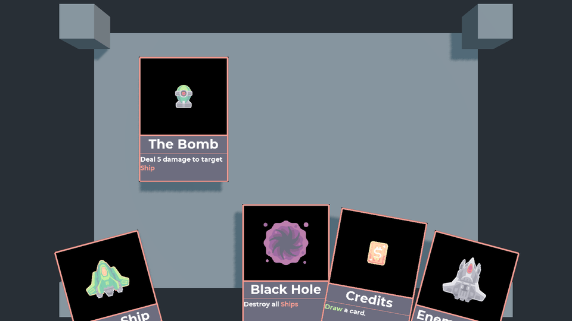

First, we need to turn the mouse position into a 3D coordinate by casting it to a point on a plane.

We can get a hold of the mouse position in screen coordinates, using `get_viewport().get_mouse_position()`.

Now, you can create a plane where you want to cast the mouse position. In code, you can define a `Plane` in a few ways. We created a `Plane` that spreads out infinitely in every direction, defined by the normal direction it faces and its distance from the world origin. We position it over the field of play at a set height.

To find where the mouse is on the `Plane`, we cast a ray straight from the camera and see where it intersects.

Conveniently, a `Camera` has a few built-in methods for casting rays that we can use as parameters for the `Plane`’s `intersect_ray()` function.

```
func get_plane_mouse_position() -> Vector2:
    var mouse_position = get_viewport().get_mouse_position()
    var drop_plane = Plane(Vector3.UP, translation.y)
    var position_in_world = drop_plane.intersects_ray(
        _camera_node.project_ray_origin(mouse_position),
        _camera_node.project_ray_normal(mouse_position)
    )
    return Vector2(position_in_world.x, position_in_world.z)
```

That’s all we need to start moving objects in 3D space with the mouse! Adding a `RemoteTransform` and moving it to the 3D coordinate.

We update the position with the `lerp()` function to make our dragging motion smoother.

```
func _process(delta: float) -> void:
    var mouse_position = get_plane_mouse_position()
    global_transform.origin.x = lerp(global_transform.origin.x, mouse_position.x, delta / smoothing)
    global_transform.origin.z = lerp(global_transform.origin.z, mouse_position.y, delta / smoothing)
```

The last step is to detect picking up and releasing the card.

You can connect the card `Area`’s `input_event` signal to a function. Then when we catch a mouse click on a card, we set the `RemoteTransform`’s `remote_path` to point to that card. Finally, we set the `remote path` to be an empty `String` whenever you release the left mouse button.

```
func _on_Card_input_event(
    _camera: Node,
    event: InputEvent,
    _click_position: Vector3,
    _click_normal: Vector3,
    _shape_idx: int,
    card_reference: Area
) -> void:
    if event.is_action_pressed("click"):
        var mouse_position := get_plane_mouse_position()
        global_transform.origin.x = mouse_position.x
        global_transform.origin.z = mouse_position.y
        set_remote_node(card_reference.get_path())

func _input(event: InputEvent) -> void:
    if event.is_action_released("click"):
        set_remote_node("")
```

The `set_remote_node()` function sets the `remote path` for our `RemoteTransform`.

The last step is to save and reset the card’s original height whenever you pick up or drop the card.

### Calling an airstrike on your enemies

Many 3D action games have objects that appear on the enemy to show the attack is occurring. Some examples are an aiming reticle, a protective aura, or explosion particles. A `RemoteTransform` is an ideal way to get positional data from your enemies so these attacks can appear on top of the enemy.

We are using this to make an airstrike center on each of our enemies.

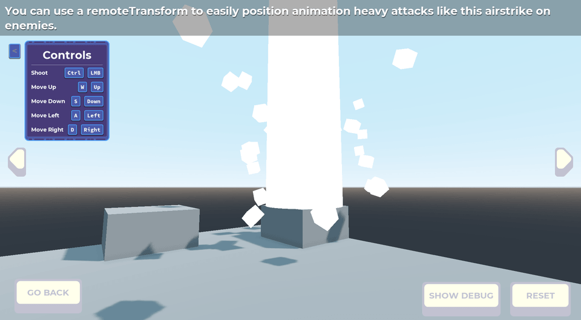

We have some simple targeting to highlight enemies and let you call in the strike if you click on them. We detect the enemies with a `RayCast`.

The specifics of our airstrike aren’t important for our implementation. In our case: we have a `MeshInstance` for the beam, `Particles` for the explosion, and an `AnimationPlayer` for sequencing.

We use a `RayCast` on the player `Camera` to find the targeted enemy - this update happens in `_physics_process()`.

```
func _physics_process(delta: float) -> void:
    if _targetting_ray.get_collider() is Enemy3D:
        _last_collider = _targetting_ray.get_collider()
        _crosshair.modulate.a = 1.0
        _last_collider.highlight()
    else:
        _crosshair.modulate.a = 0.333
        _last_collider = null
```

To bind the position of the airstrike to the enemies in our scene, each enemy has a `RemoteTransform`.

[figure not shown]

We add these `RemoteTransform` to a group: `airstrike_remote`. We do this so we can wipe the *Remote Path* of all the `RemoteTransform` nodes at once and ensure there isn’t more than one remote fighting over the position of the airstrike.

Once we wipe the `remote path` of all the `RemoteTransform`, we can update the `remote path` of the `RemoteTransform` for the enemy we just clicked on, and we can play the airstrike animation.

```
func _unhandled_input(event: InputEvent) -> void:
    if event.is_action_pressed("shoot_3d") and _last_collider:
        # In this scene all Enemy3D scenes have a RemoteTransform child.
        var enemy_remote = _last_collider.get_node("RemoteTransform")
        for node in get_tree().get_nodes_in_group("airstrike_remote"):
            node.remote_path = ""
        enemy_remote.remote_path = _airstrike.get_path()
        _airstrike_animation.play("Airstrike")
        _target = _last_collider
```

### Grinding on a rail

Paths are common for various gameplay elements, such as enemy pathfinding, grinding on rails, trains moving on train tracks, and more. But if you want these paths to update a position, the ideal pairing is the `RemoteTransform` node.

We use a `Path` and `RemoteTransform` to let the player grind on a rail when they jump on top.

For more specific detail on the process of setting up a `Path` and `PathFollow` node, check out the `Path` guide.

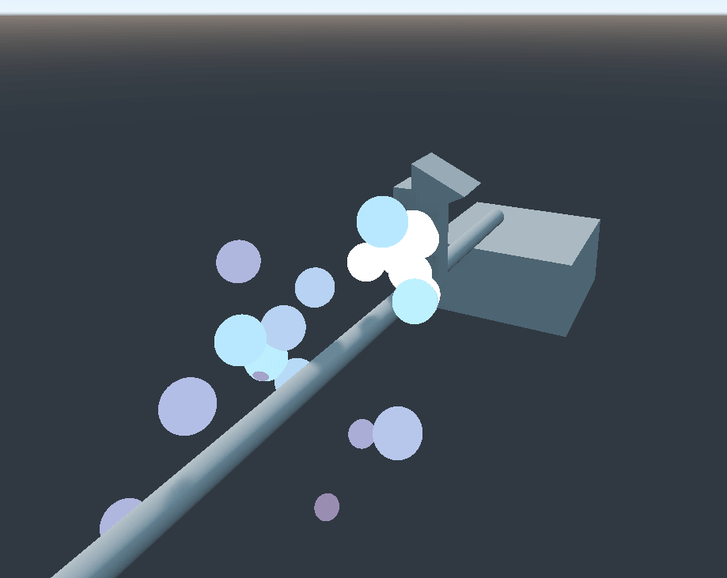

The first step is detecting collision between the rail and the player.

Our rail is an `Area` to detect the player with its `body_entered` signal. The rail scene also has our `Path`, `PathFollow`, `RemoteTransform`, and a `Tween`.

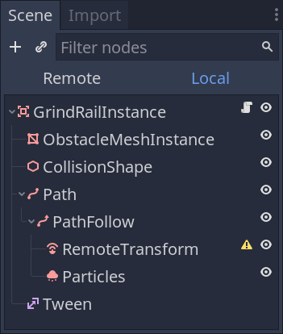

```
onready var _remote: RemoteTransform = $Path/PathFollow/RemoteTransform
onready var _particles: Particles = $Path/PathFollow/Particles
onready var _path_follow: PathFollow = $Path/PathFollow
onready var _tween: Tween = $Tween
onready var _path: Path = $Path
```

We need to move the `RemoteTransform` along the `Path` until it’s as close as possible to the player. This is to give a seamless look to the player’s attachment to the rail.

The curve within our `Path` comes with a handy `get_closest_offset()` function taking the player’s position as a parameter. Then, we can set the offset of our `PathFollow` to match and be as close as possible to the player.

```
    # Store the player position and set the PathFollow's offset to the closest position possible.
    var local_player_position: Vector3 = _path.to_local(
        player.global_transform.origin
    )
    _path_follow.offset = _path.curve.get_closest_offset(local_player_position)
```

Now that the remote is in the proper position, set the `remote_path` of the `RemoteTransform` on the `PathFollow` to be the player’s `Path`.

```
    _remote.remote_path = player.get_path()
```

The `Path` positions its `PathFollow` child with a `unit_offset` property. This property is `0.0` at one end and `1.0` at the other. We figure out what end the player is closest to with some Boolean logic. If the `unit_offset` is less than `0.5`, we set our target to `1.0`, otherwise `0.0`.

```
    var target := int(_path_follow.unit_offset < 0.5)
```

**Note:** It’s important to uncheck *Loop* on the `PathFollow` to prevent issues with the player wrapping around to the opposite side of the rail.

All that’s needed now is to use a `Tween` to move the player from one end of the `Path` to the other. Once there, you can detach the `RemoteTransform` to free the player.

We interpolate the `unit_offset` of the `PathFollow` from its current value to the previously calculated target position, then yield to wait until the `Tween` has finished:

```
    # Animate the path follow taking the player to the other end.
    _tween.interpolate_property(
        _path_follow, "unit_offset", _path_follow.unit_offset, target, 1.5
    )
    _tween.start()
    yield(_tween, "tween_all_completed")

    # When the tween ends, disable the remote transform, turn off the particles and re-enable the player.
    _remote.remote_path = ""
```

### Attaching a skateboarder to a board

You may want to attach an item to another, but still want it to be able to fall off. Examples include destructible parts of a spacecraft or passengers in a car. In our case, we have a player on a skateboard that ragdolls in a crash.

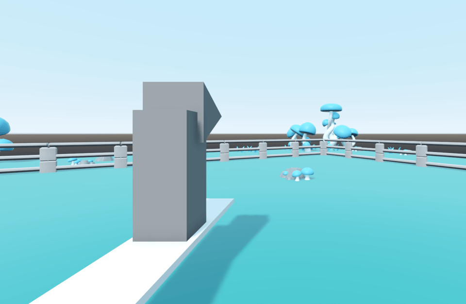

As you can guess, a `RemoteTransform` is ideal for this problem.

This node solves this problem by keeping all our nodes at the same depth in the scene tree, making it easier to set up the scene’s various elements.

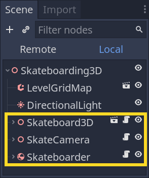

The skateboard itself requires a `RemoteTransform` and a `RigidBody` with a sphere collision shape to handle our boards motion.

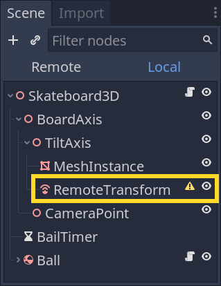

We need access to a few nodes and a `Timer` to return the player to the skateboard after a crash:

```
onready var _remote_transform: RemoteTransform = $BoardAxis/TiltAxis/RemoteTransform
onready var _bail_timer: Timer = $BailTimer
onready var tilt_axis: Spatial = $BoardAxis/TiltAxis
onready var board: Spatial = $BoardAxis
onready var ball: RigidBody = $Ball

var skateboarder: RigidBody
```

The skateboard has a `RigidBody`, so it inherits a bunch of useful functions. Increasing the `contacts_reported` property lets us detect collisions and their magnitude in the `_integrate_forces()` virtual function. This magnitude allows us to check if a crash has occurred.

```
signal crash(contact)

const COLLISION_THRESHOLD := 8.0
const VERTICAL_IMPULSE := 25

var last_velocity = Vector3.ZERO

func _integrate_forces(state: PhysicsDirectBodyState) -> void:
    # Check if any collisions exceed the threshold for a crash to occur.
    for contact in state.get_contact_count():
        var new_velocity = state.get_contact_collider_velocity_at_position(contact)
        # If the velocity has dropped by a large enough amount, our skateboarder is knocked off the board.
        if abs(new_velocity.length() - last_velocity.length()) > COLLISION_THRESHOLD:
            var impulse = last_velocity
            # Add a vertical component, to launch our skatebaorder slightly upwards
            impulse.y = VERTICAL_IMPULSE
            # The crash signal contains the former direction of motion, to launch the skateboarder in that direction
            emit_signal("crash", impulse)
        last_velocity = new_velocity
```

We attached our player character to the skateboard with our `RemoteTransform`, and it has a `Camera` that follows it around.

When the crash occurs, we want to detach the player and apply a force to launch them off the skateboard in the collision direction. We also want to disable player controls and stop the `Camera` from following. We do this by disabling the `_physics_process()` for those nodes.

```
func _on_ball_crash(collision_point: Vector3) -> void:
    if _remote_transform.remote_path.is_empty():
        return
    skateboarder = _remote_transform.get_node(_remote_transform.remote_path)
    skateboarder.camera.set_physics_process(false)
    set_physics_process(false)
    # Disable the player remote, so the ragdoll is free to fall.
    _remote_transform.remote_path = ""
    # Apply a force in the direction of the collision to the ragdoll.
    skateboarder.apply_central_impulse(collision_point)
    # Start the cooldown to reset the ragdoll.
    _bail_timer.start()
```

Lastly, we need our `Timer` `timeout` signal to reset the player’s state, attaching them to the skateboard again and enabling `_physics_process()`.

```
# Reset the ragdoll to be connected to the remote and re-enable player control.
func _on_BailTimer_timeout() -> void:
    skateboarder.linear_velocity = Vector3.ZERO
    _remote_transform.remote_path = _remote_transform.get_path_to(skateboarder)
    set_physics_process(true)
    skateboarder.camera.set_physics_process(true)
```

## Your questions

### Can I ease the transform of a remote?

As seen in the previous examples, a `RemoteTransform` immediately snaps its targets position to its own. The jump can look sudden if the two objects are far apart.

There are a few options available to ease the appearance of jumping from one position to another:

1. Use `lerp()` or a `Tween` to move the target to the remote. Then, update the `remote_path` once the target is in the right spot.
2. Move the remote to the target immediately and use `lerp()` or a `Tween` to return the remote to its original position.
3. Have a second remote as a child of the first, dedicated to moving the target to the first position of the first `RemoteTransform`.

### What’s the difference between get_node_or_null() and get_node()?

Sometimes a `RemoteTransform` can contain a `NodePath` to a node that is no longer valid due to the node being freed or moved elsewhere.

In these cases, using `get_node()` on the invalid `remote_path` causes an error to occur. If you plan on this happening, you can use an alternative function to avoid the error: `get_node_or_null()`. Instead of an error, it returns `null`. Not all `RemoteTransform` nodes need to have a `NodePath` set to remain functional in Godot.

### What are different ways of getting NodePaths?

You can get the absolute path to a node using the `get_path()` function or a relative path using `get_path_to()`.

You can also construct a `NodePath` from a string using the `NodePath()` constructor.

If you find yourself changing scene tree order a lot, you can export a `NodePath` in a script to select a node visually in the editor. This is what the Assign button on the *Remote Path* property of a `RemoteTransform` uses.

```
export var path_to_node: NodePath
```

If you only know the name of a node but not the path to it, you can use the `find_node()` function to find the child of the current node with a given name. Then you can use `get_path()` to find its path.